# Time Series Analysis

Exploring a time series using Meta’s Prophet forecasting system

Hafiz Fitri Bin Mohammed Shaufi

17 March 2024

### 1. Introduction

A time series is a variable sampled through time. We use time series for several reasons such as recognizing patterns and trends within the data. More importantly, we can use it to forecast future values based on historical data. These two things are one of the few things that I have learned in the Time Series module.

The purpose of the project is to look at the time series of CO2 concentration which is observed monthly from Jan 1959 to Dec 1997. Then, I look at forecasting the observations for another 2 years, to predict the future values of the CO2 concentration. This is done by the forecasting tool developed by Meta’s Prophet.

The data set that I used is the past observations of Mauna Loa Atmospheric CO2 Concentration. The CO2 concentrations unit are parts per million (ppm).

### 2. Data Analysis

Now, let us explore the time series of the CO2 concentration.

Prior to loading the library(prophet), I have used/installed the latest version as suggested by Meta. Then, I run the following R code below and get the following time series graph:

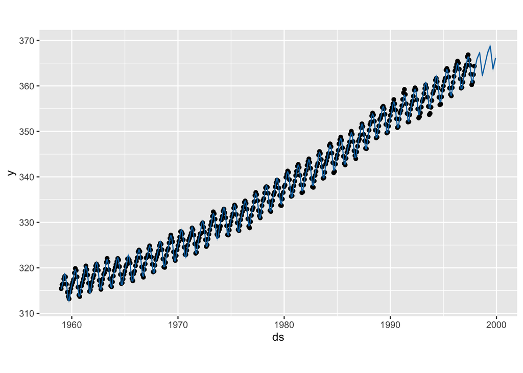

```r
co2.df = data.frame(
  ds=zoo::as.yearmon(time(co2)),
  y=co2)
NoSeasonalityModel = prophet::prophet(co2.df, daily.seasonality = FALSE, weekly.seasonality = FALSE)
Next2Year = prophet::make_future_dataframe(NoSeasonalityModel, periods=8, freq="quarter")
p = predict(NoSeasonalityModel, Next2Year)
plot(NoSeasonalityModel,p)
```

From the plot, we can see that the time series move in a consistent oscillating manner over time, that is upwards and downwards. Overall, the graph is increasing, indicating that the concentration of CO2 also getting higher over the years. We can also observe that for the next 2 years (until Jan 2000), the predicted values of CO2 concentration follows the same pattern, moving up and down but increasing.

Next, I will look at individual components of a time series using the code below that breaks time series into trend, seasonal and randomness.

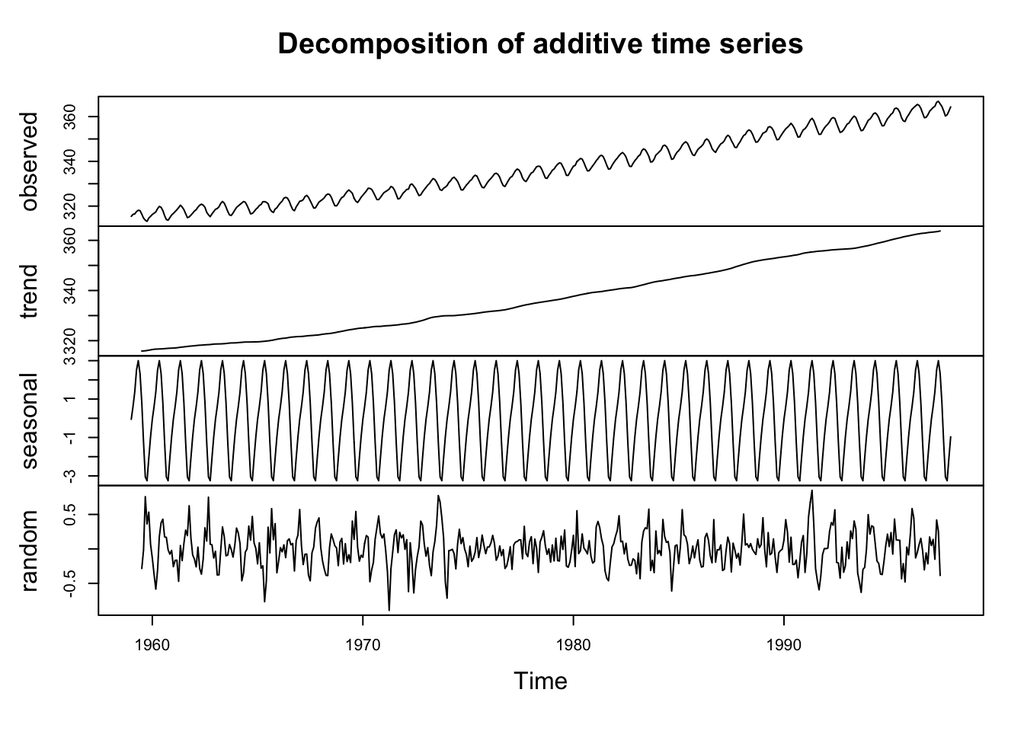

```r
plot(decompose(co2))
```

Other thing to note is the randomness or noise suggests a homoscedasticity situation. The noise is shorter for a short period, from 1975 to 1980 while the rest of the years are of the same length, on average.

For the next part, we will look at the linear regression of the model. This can be helpful to understand the relationship between number of years and CO2 concentrations.

```r
model = lm(y~ds, data = co2.df)
model
```

```
##
## Call:
## lm(formula = y ~ ds, data = co2.df)
##
## Coefficients:
## (Intercept)           ds
##   -2249.774        1.307
```

```r
summary(model)
```

```
##
## Call:
## lm(formula = y ~ ds, data = co2.df)
##
## Residuals:
##     Min      1Q  Median      3Q     Max
## -6.0399 -1.9476 -0.0017  1.9113  6.5149
##
## Coefficients:
##               Estimate Std. Error t value Pr(>|t|)
## (Intercept) -2.250e+03  2.127e+01  -105.8   <2e-16 ***
## ds           1.308e+00  1.075e-02   121.6   <2e-16 ***
## ---
## Signif. codes:  0 '***' 0.001 '**' 0.01 '*' 0.05 '.' 0.1 ' ' 1
##
## Residual standard error: 2.618 on 466 degrees of freedom
## Multiple R-squared:  0.9695, Adjusted R-squared:  0.9694
## F-statistic: 1.479e+04 on 1 and 466 DF,  p-value: < 2.2e-16
```

```r
y= fitted(model)
frequency(co2)
```

```
## [1] 12
```

### 3. Conclusion

The time series of CO2 concentration is a simple one, which is really easy to understand. From this exploration, we can conclude that the concentration of CO2 has been increasing from 1959 and is predicted to continue increasing over time, exhibiting same pattern throughout the years.